# Trabajo Práctico N° 7

Maestría en Econometría UTDT - Análisis Estadístico Multivariado

Juan Menduiña

# Ejercicio 1

*La base de datos “firmas.dta” contiene información financiera referida a dos tipos de firmas: 12 firmas consideradas de buena performance y 12 firmas no tan buenas en ese sentido. En la base, se podrán observar dos características relevadas en la totalidad de las firmas: EBITASS (ganancias después de impuestos e intereses sobre activos) y ROTC (retorno sobre el capital).*

```r
firmas <- as.data.frame(read_dta(file.path(datos, "firmas.dta")))
vars1 <- c("ebitass", "rotc")
X1 <- firmas[vars1]
g1 <- firmas$group
table(`Grupo (group)` = g1)
```

```
## Grupo (group)
##  0  1
## 12 12
```

## (a) Realizar un gráfico de las variables relevadas. Interpretar.

```r
tabla(resumen(X1), d = 4)
```

|  | Obs | Media | Desv. est. | Mín | Máx |
| --- | --- | --- | --- | --- | --- |
| ebitass | 24 | 0,0973 | 0,1074 | -0,063 | 0,280 |
| rotc | 24 | 0,0924 | 0,1065 | -0,119 | 0,236 |

```r
tabla(resumen(X1[g1 == 0, ]), d = 4)
```

|  | Obs | Media | Desv. est. | Mín | Máx |
| --- | --- | --- | --- | --- | --- |
| ebitass | 12 | 0,1913 | 0,0532 | 0,079 | 0,280 |
| rotc | 12 | 0,1835 | 0,0302 | 0,128 | 0,236 |

```r
tabla(resumen(X1[g1 == 1, ]), d = 4)
```

|  | Obs | Media | Desv. est. | Mín | Máx |
| --- | --- | --- | --- | --- | --- |
| ebitass | 12 | 0,0033 | 0,0449 | -0,063 | 0,091 |
| rotc | 12 | 0,0013 | 0,0685 | -0,119 | 0,122 |

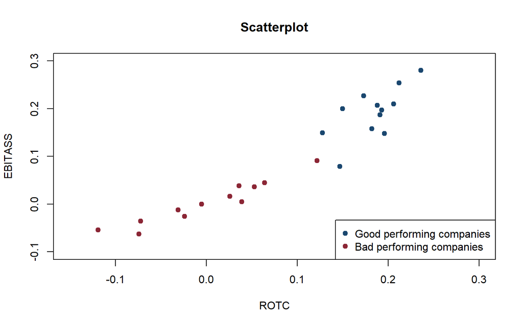

```r
plot(X1$rotc, X1$ebitass, pch = 19, col = c(azul, rojo)[g1 + 1],
     xlim = c(-0.15, 0.3), ylim = c(-0.1, 0.3),
     main = "Scatterplot", xlab = "ROTC", ylab = "EBITASS")
legend("bottomright", legend = c("Good performing companies", "Bad performing companies"),
       pch = 19, col = c(azul, rojo))
```

> *Nota: el PDF no incluye texto interpretativo para este inciso (solo el gráfico); la interpretación de abajo es una redacción propia.*

**Interpretación.** Las dos variables están fuertemente asociadas de forma positiva (a mayor retorno sobre el capital, mayor ganancia sobre activos), y las firmas de cada grupo ocupan zonas distintas del plano: las firmas del grupo 0 (“Good performing companies”) se concentran en valores altos de ambas variables, y las del grupo 1 (“Bad performing companies”), en valores bajos o negativos. Los grupos están bien separados, aunque hay una zona de solapamiento cerca de ROTC = 0,1 y EBITASS = 0,1, donde se encuentran algunas firmas de ambos grupos.

## (b) Realizar un test de medias multivariado.

```r
gm1 <- gmtest_r(X1, g1)
```

Estadístico = 34,31241761. P-value = 3,54122225e-08.

Por lo tanto, con un nivel de significancia del 1%, estos datos aportan evidencia suficiente para indicar que los grupos no tienen medias iguales.

## (c) Realizar un análisis discriminante.

Análisis discriminante lineal con probabilidades a priori de 0,5 para cada grupo:

```r
lda1 <- lda_fit(X1, g1, priors = c(0.5, 0.5))
sc1 <- lda_scores(lda1, X1)
pred1 <- lda1$niveles[max.col(sc1)]
post1 <- posterior(sc1)

tab1 <- tabla_clasif(g1, pred1, lda1$niveles)
tab1
```

```
##                Clasificado
## Grupo verdadero  0  1
##               0 12  0
##               1  1 11
```

```r
tabla_clasif_pct(tab1)
```

```
##                Clasificado
## Grupo verdadero      0      1
##               0 100.00   0.00
##               1   8.33  91.67
```

**Funciones de clasificación:**

```r
func1 <- rbind(lda1$coef, `_cons` = lda1$cons0)
colnames(func1) <- paste("group", lda1$niveles)
tabla(rbind(func1, Priors = lda1$priors), d = 5)
```

|  | group 0 | group 1 |
| --- | --- | --- |
| ebitass | 61,23745 | 2,55117 |
| rotc | 21,02689 | -1,40444 |
| _cons | -7,78760 | -0,00337 |
| Priors | 0,50000 | 0,50000 |

(Como en Stata, la constante informada no incluye el logaritmo de la probabilidad a priori; al clasificar se le suma $\ln(\pi_g)$, que con priors iguales no altera la decisión.)

La frontera de decisión (línea donde las dos funciones de clasificación son iguales) es $EBITASS = a_0 + a_1 \cdot ROTC$:

```r
dif1 <- lda1$coef[, 1] - lda1$coef[, 2]; dc1 <- lda1$cons[1] - lda1$cons[2]
a0 <- unname(-dc1 / dif1["ebitass"]); a1 <- unname(-dif1["rotc"] / dif1["ebitass"])
c(a0 = a0, a1 = a1)
```

```
##         a0         a1
##  0.1326413 -0.3822246
```

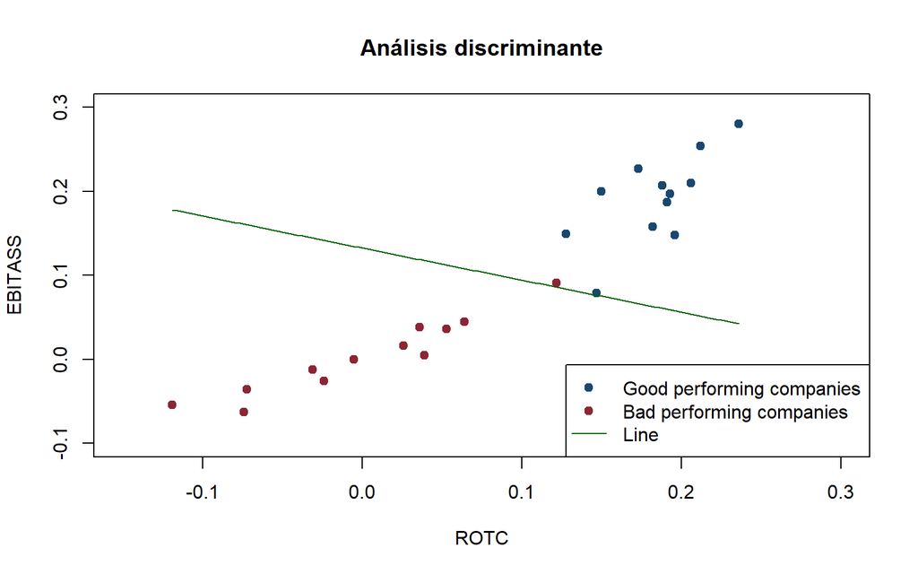

```r
plot(X1$rotc, X1$ebitass, pch = 19, col = c(azul, rojo)[g1 + 1],
     xlim = c(-0.15, 0.3), ylim = c(-0.1, 0.3),
     main = "Análisis discriminante", xlab = "ROTC", ylab = "EBITASS")
curve(a0 + a1 * x, add = TRUE, col = "darkgreen", from = min(X1$rotc), to = max(X1$rotc))
legend("bottomright", legend = c("Good performing companies", "Bad performing companies", "Line"),
       pch = c(19, 19, NA), lty = c(NA, NA, 1), col = c(azul, rojo, "darkgreen"))
```

Por lo tanto, todas las firmas del grupo 0 se clasifican correctamente (12 de 12), mientras que una firma del grupo 1 (1 de 12) se clasifica incorrectamente como del grupo 0.

> **⚠ Anotación (la redacción del PDF está invertida respecto de la tabla):** el informe dice que “todas las observaciones clasificadas en el grupo 0 están correctamente clasificadas, mientras que una de las observaciones clasificada en el grupo 1 está incorrectamente clasificada”. Según la tabla de clasificación, ocurre al revés: de las 13 firmas *clasificadas* en el grupo 0, 1 en realidad pertenece al grupo 1 (la observación 20), y las 11 firmas *clasificadas* en el grupo 1 son todas del grupo 1. Lo que sí es cierto es que las 12 firmas que *verdaderamente* son del grupo 0 se clasifican bien y que una de las 12 firmas que *verdaderamente* son del grupo 1 se clasifica mal (tasa de error de 4,17%).

## (d) Obtener predicciones para toda la muestra y comparar con la información observada.

```r
d2_1 <- sapply(1:2, function(j) mahalanobis(as.matrix(X1), lda1$mu[, j], lda1$W))
pred_tab1 <- data.frame(Obs = seq_len(nrow(X1)), True = g1, Class. = as.integer(pred1),
                        `Prob. grupo 0` = post1[, 1], `Prob. grupo 1` = post1[, 2],
                        `Mahalanobis² al grupo 0` = d2_1[, 1], `Mahalanobis² al grupo 1` = d2_1[, 2],
                        Error = ifelse(g1 != as.integer(pred1), "*", ""), check.names = FALSE)
tabla(pred_tab1, d = 4)
```

| Obs | True | Class. | Prob. grupo 0 | Prob. grupo 1 | Mahalanobis² al grupo 0 | Mahalanobis² al grupo 1 | Error |
| --- | --- | --- | --- | --- | --- | --- | --- |
| 1 | 0 | 0 | 0,9962 | 0,0038 | 1,0939 | 12,2353 |  |
| 2 | 0 | 0 | 0,9999 | 0,0001 | 0,1863 | 18,5078 |  |
| 3 | 0 | 0 | 0,9998 | 0,0002 | 0,1689 | 17,3308 |  |
| 4 | 0 | 0 | 1,0000 | 0,0000 | 3,6736 | 31,5571 |  |
| 5 | 0 | 0 | 0,9997 | 0,0003 | 0,0338 | 16,2462 |  |
| 6 | 0 | 0 | 0,9999 | 0,0001 | 2,0086 | 20,8450 |  |
| 7 | 0 | 0 | 0,9950 | 0,0050 | 2,9421 | 13,5379 |  |
| 8 | 0 | 0 | 1,0000 | 0,0000 | 2,1438 | 25,8989 |  |
| 9 | 0 | 0 | 0,5373 | 0,4627 | 8,2253 | 8,5241 |  |
| 10 | 0 | 0 | 0,9788 | 0,0212 | 1,1030 | 8,7655 |  |
| 11 | 0 | 0 | 0,9993 | 0,0007 | 1,5424 | 16,1779 |  |
| 12 | 0 | 0 | 0,9994 | 0,0006 | 0,1205 | 15,0694 |  |
| 13 | 1 | 1 | 0,0001 | 0,9999 | 18,8068 | 0,4391 |  |
| 14 | 1 | 1 | 0,0112 | 0,9888 | 9,9452 | 0,9799 |  |
| 15 | 1 | 1 | 0,0086 | 0,9914 | 10,0180 | 0,5248 |  |
| 16 | 1 | 1 | 0,0000 | 1,0000 | 28,4475 | 2,1647 |  |
| 17 | 1 | 1 | 0,0000 | 1,0000 | 33,3403 | 6,0950 |  |
| 18 | 1 | 1 | 0,0004 | 0,9996 | 15,8082 | 0,0154 |  |
| 19 | 1 | 1 | 0,0013 | 0,9987 | 14,4351 | 1,2031 |  |
| 20 | 1 | 0 | 0,5727 | 0,4273 | 4,6140 | 5,1997 | * |
| 21 | 1 | 1 | 0,0000 | 1,0000 | 25,1373 | 2,1134 |  |
| 22 | 1 | 1 | 0,0239 | 0,9761 | 8,8352 | 1,4197 |  |
| 23 | 1 | 1 | 0,0001 | 0,9999 | 20,0519 | 0,3551 |  |
| 24 | 1 | 1 | 0,0019 | 0,9981 | 12,7719 | 0,2478 |  |

(`*` indica las observaciones mal clasificadas.) La única observación mal clasificada es la 20, con probabilidad a posteriori de 0,5727 para el grupo 0 y 0,4273 para el grupo 1, es decir, una clasificación poco concluyente (la observación 9 también tiene una probabilidad cercana al 50%, pero está bien clasificada).

## (e) Considerar una firma con un EBITASS y un ROTC de 0,1. ¿En qué grupo se la clasificaría?

```r
nueva <- data.frame(ebitass = 0.1, rotc = 0.1)
sc_n <- lda_scores(lda1, nueva)
cbind(`Puntaje grupo 0` = sc_n[1, 1], `Puntaje grupo 1` = sc_n[1, 2], posterior(sc_n))
```

```
##   Puntaje grupo 0 Puntaje grupo 1         0         1
## 0      -0.2543131      -0.5818487 0.5811596 0.4188404
```

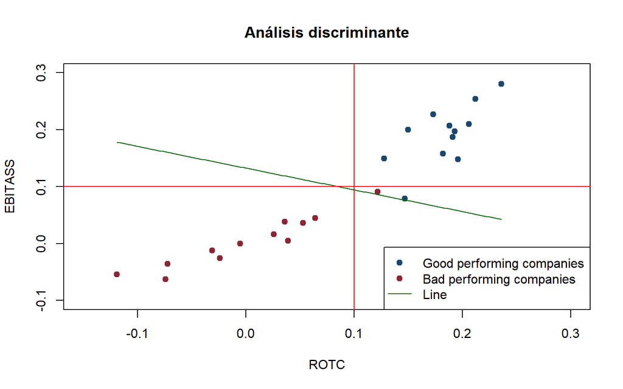

```r
plot(X1$rotc, X1$ebitass, pch = 19, col = c(azul, rojo)[g1 + 1],
     xlim = c(-0.15, 0.3), ylim = c(-0.1, 0.3),
     main = "Análisis discriminante", xlab = "ROTC", ylab = "EBITASS")
curve(a0 + a1 * x, add = TRUE, col = "darkgreen", from = min(X1$rotc), to = max(X1$rotc))
abline(h = 0.1, v = 0.1, col = "red")
legend("bottomright", legend = c("Good performing companies", "Bad performing companies", "Line"),
       pch = c(19, 19, NA), lty = c(NA, NA, 1), col = c(azul, rojo, "darkgreen"))
```

Por lo tanto, considerando una firma con un EBITASS y un ROTC de 0,1, se la clasificaría en el grupo 0 (“Good performing companies”). Cabe aclarar que el punto está cerca de la frontera de decisión (probabilidad a posteriori de 0,581 para el grupo 0), por lo que la clasificación es poco concluyente.

# Ejercicio 2

*La base de datos “muestra_engh.dta” contiene información proveniente de la Encuesta Nacional de Gastos de los Hogares para tres regiones: Metropolitana, Noreste (NEA) y Sur. Considerar responder a las siguientes consignas con las variables desagregadas por capítulo de gasto.*

[output not shown]

```r
engh <- as.data.frame(read_dta(file.path(datos, "muestra_engh.dta")))
vars2 <- paste0("cap", 1:9)
engh <- engh[complete.cases(engh[c("region", vars2)]), ]
X2 <- engh[vars2]
g2 <- factor(engh$region)
id2 <- as.integer(g2)           # 1, 2, 3 = regiones 1, 4, 6
groups2 <- nlevels(g2)
table(`Región` = engh$region)
```

```
## Región
##   1   4   6
## 120 135 166
```

## (a) Realizar un test de igualdad de medias entre regiones.

```r
cat("\n**Total:**\n\n"); print(tabla(resumen(X2), d = 3))
```

**Total:**

|  | Obs | Media | Desv. est. | Mín | Máx |
| --- | --- | --- | --- | --- | --- |
| cap1 | 421 | 301,820 | 229,287 | 0,00 | 1467,34 |
| cap2 | 421 | 76,873 | 127,495 | 0,00 | 1218,60 |
| cap3 | 421 | 103,551 | 143,338 | 0,00 | 1259,50 |
| cap4 | 421 | 78,240 | 136,396 | 0,00 | 1119,20 |
| cap5 | 421 | 56,410 | 141,340 | 0,00 | 1439,00 |
| cap6 | 421 | 147,728 | 308,184 | -512,99 | 2813,87 |
| cap7 | 421 | 70,742 | 144,326 | 0,00 | 2071,33 |
| cap8 | 421 | 26,317 | 67,493 | 0,00 | 640,00 |
| cap9 | 421 | 48,725 | 150,589 | 0,00 | 2841,74 |

```r
for (r in levels(g2)) {
  cat("\n\n**Región ", r, ":**\n\n", sep = "")
  print(tabla(resumen(X2[g2 == r, ]), d = 3))
}
```

**Región 1:**

|  | Obs | Media | Desv. est. | Mín | Máx |
| --- | --- | --- | --- | --- | --- |
| cap1 | 120 | 323,279 | 209,918 | 0,00 | 991,37 |
| cap2 | 120 | 54,638 | 82,023 | 0,00 | 445,00 |
| cap3 | 120 | 104,733 | 159,376 | 0,00 | 1259,50 |
| cap4 | 120 | 79,966 | 163,029 | 0,00 | 1119,20 |
| cap5 | 120 | 110,513 | 213,506 | 0,00 | 1439,00 |
| cap6 | 120 | 125,127 | 188,500 | -211,46 | 1338,56 |
| cap7 | 120 | 76,904 | 136,927 | 0,00 | 1207,67 |
| cap8 | 120 | 32,439 | 80,279 | 0,00 | 640,00 |
| cap9 | 120 | 41,151 | 54,978 | 0,00 | 387,93 |

**Región 4:**

|  | Obs | Media | Desv. est. | Mín | Máx |
| --- | --- | --- | --- | --- | --- |
| cap1 | 135 | 263,400 | 156,296 | 12,12 | 772,11 |
| cap2 | 135 | 51,795 | 72,738 | 0,00 | 544,00 |
| cap3 | 135 | 89,049 | 120,140 | 0,00 | 794,50 |
| cap4 | 135 | 58,535 | 97,410 | 0,00 | 659,45 |
| cap5 | 135 | 27,027 | 54,307 | 0,00 | 369,40 |
| cap6 | 135 | 81,224 | 197,250 | -512,99 | 1542,82 |
| cap7 | 135 | 38,945 | 53,486 | 0,00 | 296,27 |
| cap8 | 135 | 18,195 | 52,640 | 0,00 | 315,70 |
| cap9 | 135 | 31,464 | 64,743 | 0,00 | 602,82 |

**Región 6:**

|  | Obs | Media | Desv. est. | Mín | Máx |
| --- | --- | --- | --- | --- | --- |
| cap1 | 166 | 317,552 | 283,567 | 0 | 1467,34 |
| cap2 | 166 | 113,341 | 173,250 | 0 | 1218,60 |
| cap3 | 166 | 114,490 | 148,201 | 0 | 874,93 |
| cap4 | 166 | 93,017 | 141,213 | 0 | 750,60 |
| cap5 | 166 | 41,196 | 111,855 | 0 | 1000,01 |
| cap6 | 166 | 218,151 | 418,995 | 0 | 2813,87 |
| cap7 | 166 | 92,145 | 189,370 | 0 | 2071,33 |
| cap8 | 166 | 28,496 | 67,904 | 0 | 373,21 |
| cap9 | 166 | 68,238 | 226,872 | 0 | 2841,74 |

```r
gm2 <- gmtest_r(X2, g2)
```

Estadístico = 72,80066507. P-value = 1,50900287e-08.

Por lo tanto, con un nivel de significancia del 1%, estos datos aportan evidencia suficiente para indicar que los grupos no tienen medias iguales.

## (b) Realizar un análisis discriminante.

Siguiendo el do-file, se calcula la matriz de varianzas y covarianzas **total** $S$ de las 9 variables y, para cada región $i$, el vector de medias $\mu_i$, los coeficientes $\alpha_i' = \mu_i' S^{-1}$ y la constante $c_i = \alpha_i' \mu_i$:

```r
S2 <- cov(X2)
S2_inv <- solve(S2)
medias2 <- sapply(1:groups2, function(i) colMeans(X2[id2 == i, ]))     # 9 x 3
alpha2 <- t(medias2) %*% S2_inv                                          # 3 x 9
c2 <- rowSums(alpha2 * t(medias2))                                       # c_i = alpha_i' mu_i
colnames(medias2) <- paste0("región ", levels(g2)); rownames(alpha2) <- paste0("alpha_", 1:groups2)
tabla(medias2, d = 3)
```

|  | región 1 | región 4 | región 6 |
| --- | --- | --- | --- |
| cap1 | 323,279 | 263,400 | 317,552 |
| cap2 | 54,638 | 51,795 | 113,341 |
| cap3 | 104,733 | 89,049 | 114,490 |
| cap4 | 79,966 | 58,535 | 93,017 |
| cap5 | 110,513 | 27,027 | 41,196 |
| cap6 | 125,127 | 81,224 | 218,151 |
| cap7 | 76,904 | 38,945 | 92,145 |
| cap8 | 32,439 | 18,195 | 28,496 |
| cap9 | 41,151 | 31,464 | 68,238 |

```r
tabla(alpha2, d = 6)
```

|  | cap1 | cap2 | cap3 | cap4 | cap5 | cap6 | cap7 | cap8 | cap9 |
| --- | --- | --- | --- | --- | --- | --- | --- | --- | --- |
| alpha_1 | 0,006241 | -0,001951 | 0,001890 | -0,000885 | 0,002835 | -0,000726 | 0,000575 | 0,001943 | 0,000137 |
| alpha_2 | 0,005398 | -0,000716 | 0,002834 | 0,000464 | -0,001498 | -0,001049 | -0,000561 | 0,000821 | 0,000304 |
| alpha_3 | 0,004911 | 0,002361 | 0,003013 | -0,000442 | -0,001681 | 0,000009 | 0,001316 | 0,000938 | 0,000655 |

```r
tabla(data.frame(Región = levels(g2), `c_i` = c2), d = 6)
```

| Región | c_i |
| --- | --- |
| 1 | 2,373450 |
| 4 | 1,541215 |
| 6 | 2,256341 |

## (c) Obtener las predicciones a partir de la/s estimación/es de la función/es discriminante/s.

La puntuación de cada región es $p_i = \alpha_i' x - c_i/2$, y se clasifica cada hogar en la región con mayor puntuación:

```r
P2 <- as.matrix(X2) %*% t(alpha2)
P2 <- sweep(P2, 2, c2 / 2, "-")
predict1 <- max.col(P2)
table(predict1)
```

```
## predict1
##   1   2   3
##  86 233 102
```

## (d) Obtener las predicciones a partir de las distancias de Mahalanobis.

Se clasifica cada hogar en la región cuyo vector de medias esté más cerca en la distancia de Mahalanobis $d_i = (x - \mu_i)' S^{-1} (x - \mu_i)$:

```r
D2 <- sapply(1:groups2, function(i) mahalanobis(as.matrix(X2), medias2[, i], S2))
predict2 <- max.col(-D2)
table(predict1 = predict1, predict2 = predict2)
```

```
##         predict2
## predict1   1   2   3
##        1  86   0   0
##        2   0 233   0
##        3   0   0 102
```

Las dos reglas son equivalentes: como $d_i = x'S^{-1}x - 2\alpha_i'x + c_i$, minimizar la distancia de Mahalanobis equivale a maximizar $\alpha_i'x - c_i/2$, por lo que las predicciones coinciden en todos los casos (la tabla es diagonal).

## (e) Completar una tabla de predicción-realización.

```r
tab2 <- table(`Región (id)` = factor(id2, labels = paste0("id_", 1:groups2)),
              Predicción = factor(predict1, levels = 1:groups2, labels = paste0("predict_", 1:groups2)))
tab2
```

```
##            Predicción
## Región (id) predict_1 predict_2 predict_3
##        id_1        44        60        16
##        id_2        20        96        19
##        id_3        22        77        67
```

```r
ok2 <- sum(diag(tab2))
wr2 <- nrow(X2) - ok2
```

Correct = 207. Incorrect = 214.

Por lo tanto, 207 y 214 observaciones fueron clasificadas correcta e incorrectamente, respectivamente.

Análisis discriminante lineal estándar (`discrim lda`, con covarianza intra-grupos conjunta y probabilidades a priori iguales):

```r
lda2 <- lda_fit(X2, id2)
pred_lda2 <- max.col(lda_scores(lda2, X2))
tab_lda2 <- table(`Región (id)` = factor(id2), Clasificado = factor(pred_lda2, levels = 1:groups2))
tab_lda2
```

```
##            Clasificado
## Región (id)  1  2  3
##           1 44 60 16
##           2 20 96 19
##           3 23 75 68
```

```r
tabla_clasif_pct(tab_lda2)
```

```
##            Clasificado
## Región (id)     1     2     3
##           1 36.67 50.00 13.33
##           2 14.81 71.11 14.07
##           3 13.86 45.18 40.96
```

> **⚠ Anotación (diferencia entre la regla del do-file y el análisis discriminante lineal estándar):** la tabla de predicción-realización del inciso (e) se obtiene con la covarianza **total** $S$ de toda la muestra (como en el do-file), pero el análisis discriminante lineal supone una matriz de covarianzas común **intra-grupos** (la covarianza conjunta de los grupos, con denominador $N - G$). Por eso los resultados difieren levemente: 207 aciertos con la regla del do-file frente a 208 con `discrim lda`, y la distribución de la clasificación no es idéntica (por ejemplo, la región 3 pasa de 22, 77, 67 a 23, 75, 68 observaciones clasificadas en cada región). El informe presenta ambas tablas sin comentar la diferencia. Además, estas tasas de acierto son de *resustitución* (se evalúa con los mismos datos con que se estima) y, por lo tanto, son optimistas.

## (f) ¿Cómo se realizaría el análisis en caso de no poder suponer que las matrices de varianzas y covarianzas son iguales entre grupos? ¿Cuántos parámetros se deberían estimar?

Si no se puede suponer que las matrices de varianzas y covarianzas son iguales entre grupos, se estima una matriz de covarianzas $S_g$ para cada grupo y se aplica el análisis discriminante **cuadrático**: cada observación se asigna al grupo que minimiza $\tfrac{1}{2}(x - \mu_g)'S_g^{-1}(x - \mu_g) + \tfrac{1}{2}\ln|S_g|$ (con probabilidades a priori iguales):

```r
Sg <- lapply(1:groups2, function(i) cov(X2[id2 == i, ]))
cg <- sapply(Sg, function(S) log(det(S)) / 2)
names(cg) <- paste0("c", 1:groups2)
cg
```

```
##       c1       c2       c3
## 41.89741 39.34290 45.51979
```

```r
D_new <- sapply(1:groups2, function(i) mahalanobis(as.matrix(X2), medias2[, i], Sg[[i]]) / 2 + cg[i])
predict2_new <- max.col(-D_new)
tab2_new <- table(`Región (id)` = factor(id2, labels = paste0("id_", 1:groups2)),
                  Predicción = factor(predict2_new, levels = 1:groups2, labels = paste0("predict_", 1:groups2)))
tab2_new
```

```
##            Predicción
## Región (id) predict_1 predict_2 predict_3
##        id_1        36        72        12
##        id_2        12       113        10
##        id_3        22       100        44
```

```r
ok2_new <- sum(diag(tab2_new))
```

Correct = 193. Incorrect = 228.

Por lo tanto, 193 y 228 observaciones fueron clasificadas correcta e incorrectamente, respectivamente.

Análisis discriminante cuadrático estándar (`discrim qda`):

```r
pred_qda2 <- max.col(qda_scores(X2, id2))
tab_qda2 <- table(`Región (id)` = factor(id2), Clasificado = factor(pred_qda2, levels = 1:groups2))
tab_qda2
```

```
##            Clasificado
## Región (id)   1   2   3
##           1  36  72  12
##           2  12 113  10
##           3  22 100  44
```

```r
tabla_clasif_pct(tab_qda2)
```

```
##            Clasificado
## Región (id)     1     2     3
##           1 30.00 60.00 10.00
##           2  8.89 83.70  7.41
##           3 13.25 60.24 26.51
```

La regla del do-file coincide con `discrim qda` (las predicciones son idénticas): TRUE.

**Cantidad de parámetros.** Con $p = 9$ variables y $G = 3$ grupos:

```r
p <- 9; G <- 3
tabla(data.frame(
  Modelo = c("Lineal (covarianza común)", "Cuadrático (una covarianza por grupo)"),
  `Medias` = G * p,
  `Covarianzas` = c(p * (p + 1) / 2, G * p * (p + 1) / 2),
  `Probabilidades a priori` = G - 1,
  `Total` = c(G * p + p * (p + 1) / 2 + (G - 1), G * p + G * p * (p + 1) / 2 + (G - 1)),
  check.names = FALSE), d = 0)
```

| Modelo | Medias | Covarianzas | Probabilidades a priori | Total |
| --- | --- | --- | --- | --- |
| Lineal (covarianza común) | 27 | 45 | 2 | 74 |
| Cuadrático (una covarianza por grupo) | 27 | 135 | 2 | 164 |

En el caso lineal se estiman 3 vectores de medias (27 parámetros) y una matriz de covarianzas común (45 parámetros); en el cuadrático, 3 vectores de medias (27) y 3 matrices de covarianzas (135 parámetros), es decir, 162 parámetros (más 2 si se estiman las probabilidades a priori). El costo es una mayor varianza de estimación, sobre todo con grupos pequeños.

> *Nota: el PDF no responde la pregunta sobre cuántos parámetros se deben estimar (solo muestra la tabla de clasificación del análisis cuadrático); el recuento de arriba es una redacción propia. Por otro lado, en esta muestra el análisis cuadrático no mejora la clasificación (193 aciertos frente a 208 del lineal), lo que sugiere que la mayor flexibilidad no compensa el aumento de parámetros a estimar.*